# Biostat 203B Homework 4

Due Mar 12 Mar 19 @ 11:59PM

Alvin Wang

Load database libraries and the tidyverse frontend:

```r
library(dplyr)
library(mice)
library(miceRanger)
library(doParallel)
library(fastDummies)
library(glmnet)
library(keras)
```

## Q1. Missing data

Through the Shiny app developed in HW3, we observe abundant missing values in the MIMIC-IV ICU cohort we created. In this question, we use multiple imputation to obtain a data set without missing values.

0. Read following tutorials on the R package miceRanger for imputation: https://github.com/farrellday/miceRanger, https://cran.r-project.org/web/packages/miceRanger/vignettes/miceAlgorithm.html.

   A more thorough book treatment of the practical imputation strategies is the book [*Flexible Imputation of Missing Data*](https://stefvanbuuren.name/fimd/) by Stef van Buuren.
1. Explain the jargon MCAR, MAR, and MNAR.

MCAR: If the probability of being missing is the same for all cases, then the data are said to be missing completely at random (MCAR).

MAR: If the probability of being missing is the same only within groups defined by the observed data, then the data are missing at random (MAR).

MNAR: MNAR (missing not at random) means that the probability of being missing varies for reasons that are unknown to us.

2. Explain in a couple of sentences how the Multiple Imputation by Chained Equations (MICE) work.

MICE imputes missing values in the variables of a data set by using a divide and conquer approach - in other words, by focusing on one variable at a time. Once the focus is placed on one variable, MICE uses all the other variables in the data set (or a sensibly chosen subset of these variables) to predict missingness in that variable. The prediction is based on a regression model, with the form of the model depending on the nature of the focus variable.

3. Perform a data quality check of the ICU stays data. Discard variables with substantial missingness, say >5000 `NA`s. Replace apparent data entry errors by `NA`s.

```r
icu_cohort <- readRDS("icu_cohort.rds")

#Remove variables we don't need
icu_cohort <- icu_cohort %>%
  subset(select = -c(deathtime,edouttime,edregtime,dod,lactate,
                     arterial_blood_pressure_systolic,
                     arterial_blood_pressure_mean,subject_id,hadm_id,stay_id.x,
                     stay_id.y,intime,outtime,admittime,dischtime))

colSums(is.na(icu_cohort))
```

```
##                       first_careunit                        last_careunit
##                                    0                                    0
##                                  los                               gender
##                                    0                                    0
##                           anchor_age                          anchor_year
##                                    0                                    0
##                    anchor_year_group                       admission_type
##                                    0                                    0
##                   admission_location                   discharge_location
##                                    0                                  452
##                            insurance                             language
##                                    0                                    0
##                       marital_status                            ethnicity
##                                 4176                                    0
##                 hospital_expire_flag                           age_at_adm
##                                    0                                    0
##                          bicarbonate                              calcium
##                                  861                                 2374
##                             chloride                           creatinine
##                                  835                                  839
##                              glucose                            magnesium
##                                  850                                 1017
##                            potassium                               sodium
##                                  852                                  826
##                           hematocrit                                  wbc
##                                 1016                                 1032
##                           heart_rate non_invasive_blood_pressure_systolic
##                                  720                                 1252
##     non_invasive_blood_pressure_mean                     respiratory_rate
##                                 1273                                  742
##               temperature_fahrenheit                             death_30
##                                 1517                                    0
```

```r
#Replace data entries by NAs.
rep_na <- function(x){
  if(is.numeric(x)){
    quantiles <- quantile(x, c(.025, .975),na.rm = TRUE)
    x[x < quantiles[1]] <- NA
    x[x > quantiles[2]] <- NA
  }
  return(x)
}
icu_cohort <- lapply(icu_cohort, rep_na) %>% as.data.frame()
```

4. Impute missing values by `miceRanger` (request $m=3$ datasets). This step is very computational intensive. Make sure to save the imputation results as a file.

```r
#Imputation
# Set up back ends.
cl <- makeCluster(8)
registerDoParallel(cl)

seqTime <- system.time(
  icu_mice <- miceRanger(
    icu_cohort
    , m = 3
    , returnModels = TRUE
    , verbose = TRUE
    , parallel = TRUE
    , max.depth = 5
  )
)
stopCluster(cl)
registerDoSEQ()
saveRDS(icu_mice, file = "icu_mice.rds")
```

5. Make imputation diagnostic plots and explain what they mean.

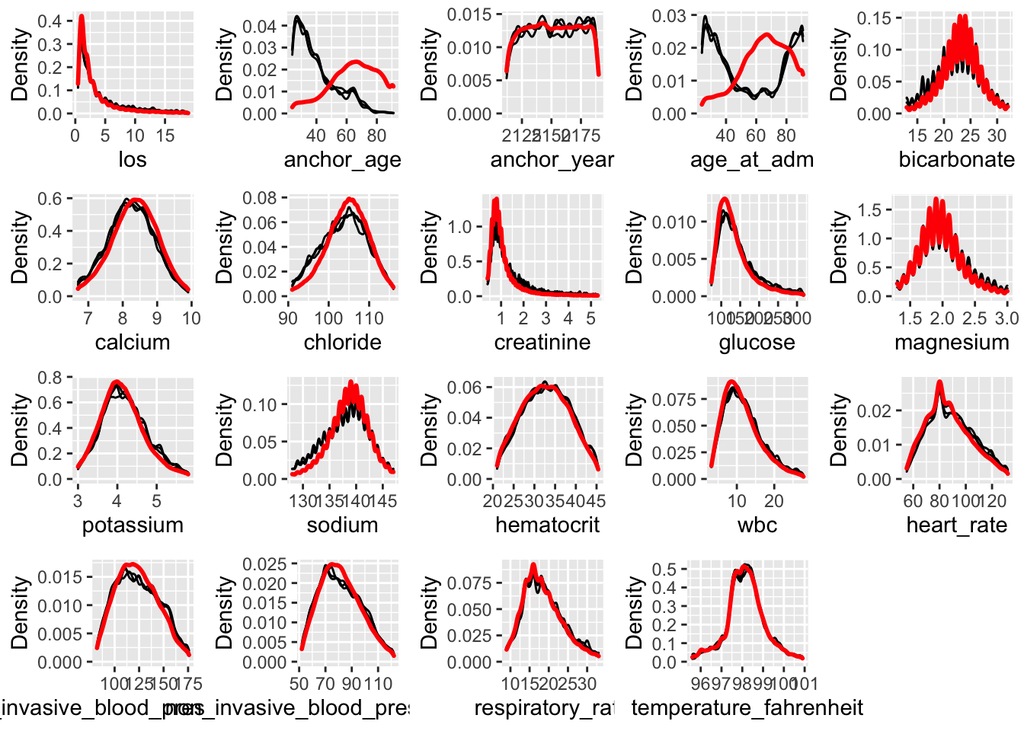

```r
icu_mice <- readRDS("icu_mice.rds")
plotDistributions(icu_mice, var = 'allNumeric')
```

There are the distribution plots of the imputed values. The red lines stand for the densities of the original data while the black lines stand for the densities of the imputed values.

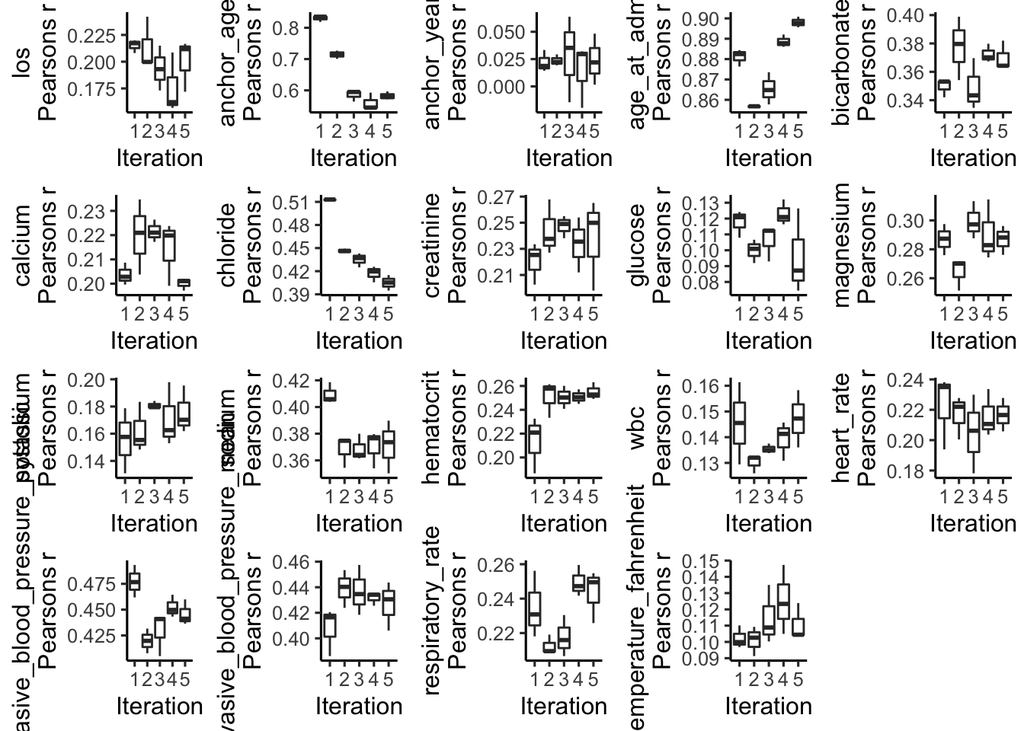

```r
plotCorrelations(icu_mice, vars = 'allNumeric')
```

This function shows a boxplot of the correlations between imputed values in every combination of datasets.

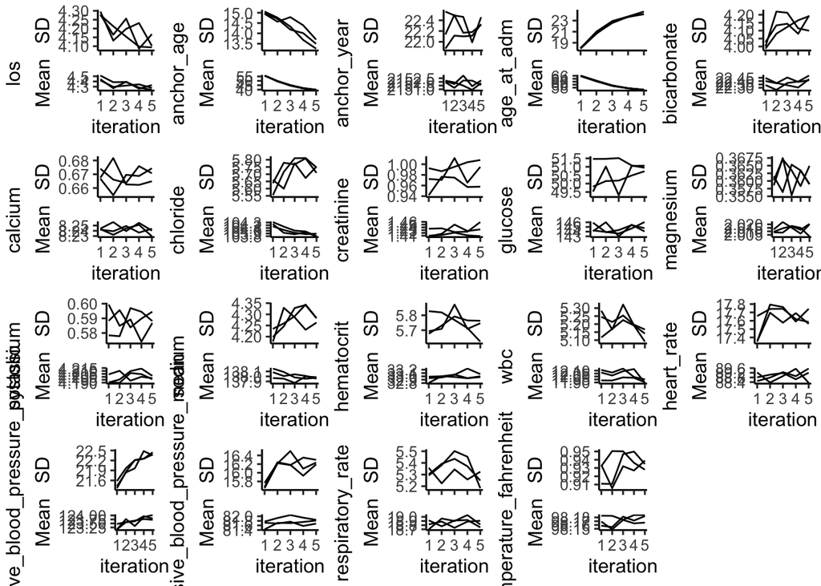

```r
plotVarConvergence(icu_mice, vars = 'allNumeric')
```

From the convergence plots, we can tell whether daata converge to the true theoretical mean (given the information that exists in the dataset). We can see if the imputed data converged, or if we need to run more iterations.

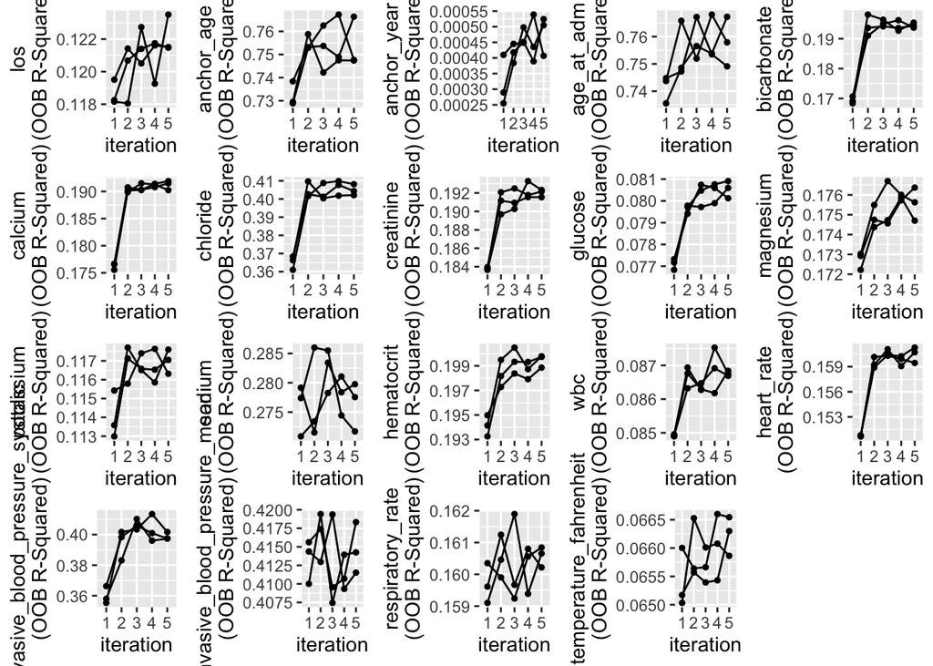

```r
plotModelError(icu_mice, vars = 'allNumeric')
```

Modell OOB error plots give us a way to determine model error without cross validation. Each model returns the OOB accuracy for classification, and r-squared for regression.

6. Obtain a complete data set by averaging the 3 imputed data sets.

```r
#define variables of interest
dataList <- completeData(icu_mice)
vars = c("gender", "age_at_adm", "marital_status", "ethnicity", "bicarbonate",
         "calcium", "chloride", "creatinine", "glucose", "magnesium",
         "potassium", "sodium", "hematocrit", "wbc", "heart_rate",
         "non_invasive_blood_pressure_systolic",
         "non_invasive_blood_pressure_mean", "respiratory_rate",
         "temperature_fahrenheit", "death_30")
dataset1 <- dataList$Dataset_1 %>% subset(select = vars)
data1 <- dummy_cols(dataset1,
           remove_first_dummy = TRUE,
           remove_selected_columns = TRUE)
dataset2 <- dataList$Dataset_2 %>% subset(select = vars)
data2 <- dummy_cols(dataset2,
                    remove_first_dummy = TRUE,
                    remove_selected_columns = TRUE)
dataset3 <- dataList$Dataset_3 %>% subset(select = vars)
data3 <- dummy_cols(dataset3,
                    remove_first_dummy = TRUE,
                    remove_selected_columns = TRUE)
#obtain average of 3 imputed datasets
final_dataset <- (data1 + data2 + data3) / 3
final_dataset <- final_dataset %>%
  mutate_at(vars("marital_status_MARRIED": "marital_status_WIDOWED"), round)
```

## Q2. Predicting 30-day mortality

Develop at least two analytic approaches for predicting the 30-day mortality of patients admitted to ICU using demographic information (gender, age, marital status, ethnicity), first lab measurements during ICU stay, and first vital measurements during ICU stay. For example, you can use (1) logistic regression (`glm()` function), (2) logistic regression with lasso penalty (glmnet package), (3) random forest (randomForest package), or (4) neural network.

1. Partition data into 80% training set and 20% test set. Stratify partitioning according the 30-day mortality status.

```r
set.seed(101) # Set Seed so that same sample can be reproduced in future also
# Now Selecting 80% of data as sample from total 'n' rows of the data
sample <- sample.int(n = nrow(final_dataset),
                     size = floor(.8*nrow(final_dataset)), replace = F)
train <- final_dataset[sample, ]
test  <- final_dataset[-sample, ]
train_x <- train %>% subset(select = -c(death_30_Yes)) %>% as.matrix()
train_y <- train$death_30_Yes %>% as.matrix()
test_x <- test %>% subset(select = -c(death_30_Yes)) %>% as.matrix()
test_y <- test$death_30_Yes %>% as.matrix()
```

2. Train the models using the training set.

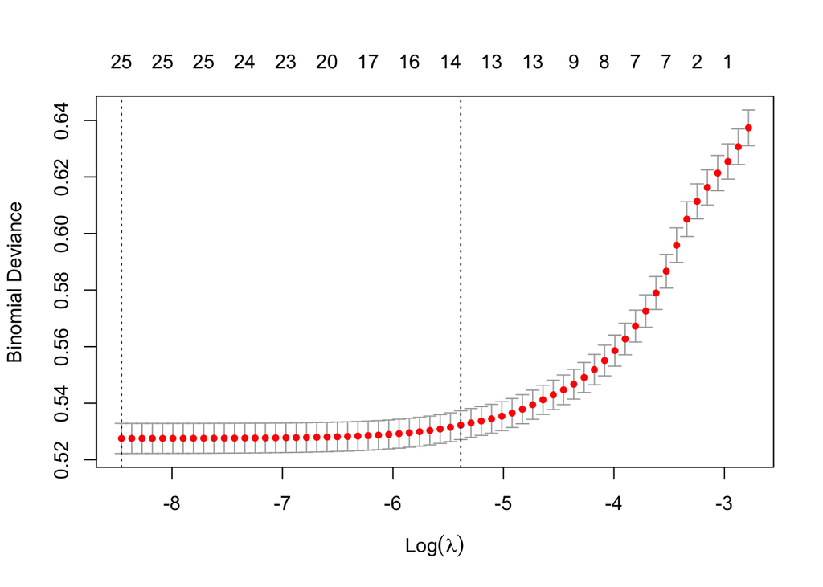

```r
#GLM lasso
glmmod <- cv.glmnet(train_x, y=train_y, alpha=1, family="binomial")
plot(glmmod, xvar="lambda")
```

```r
#MLP
model <- keras_model_sequential()
# Add layers to the model
model %>%
  layer_dense(units = 32, activation = 'relu',
              bias_initializer = initializer_constant(0.01),
              kernel_initializer = "uniform", input_shape = c(27)) %>%
  layer_dropout(rate = 0.4) %>%
  layer_dense(units = 16, activation = 'relu',
              bias_initializer = initializer_constant(0.01),
              kernel_initializer = "uniform") %>%
  layer_dropout(rate = 0.3) %>%
  layer_dense(units = 1, activation  = "sigmoid")
# Compile the model
model %>% compile(
  loss = 'binary_crossentropy',
  optimizer = 'adam',
  metrics = 'accuracy'
)
# Fit the model
system.time({
  history <- model %>% fit(
  as.matrix(train_x),
  as.matrix(train$death_30_Yes),
  epochs = 100,
  batch_size = 128,
  class_weight = list("0" = 1, "1" = 6),
  validation_split = 0.3
  )
})
```

```
##    user  system elapsed
##  49.620   7.971  38.705
```

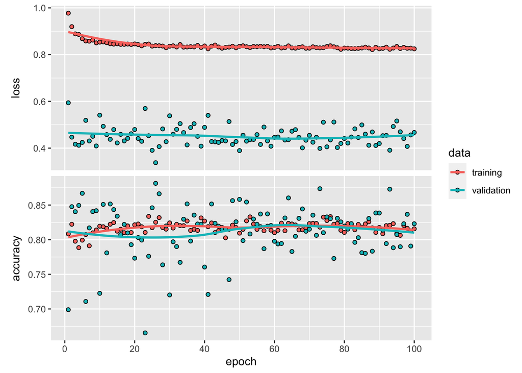

```r
plot(history)
```

```r
#model %>% evaluate(as.matrix(test1), as.matrix(test$death_30_Yes))
#results <- model %>% predict_classes(as.matrix(test1))
#table(results)
```

3. Compare model prediction performance on the test set.

Performance of GLM lasso:

```r
pre <- predict(glmmod, newx = test_x, type = "response", s = min(glmmod$lambda))
pre <- round(pre)
performance <- 1 - (sum(abs(pre - test_y)) / length(pre)) %>% print()
```

```
## [1] 0.0986014
```

Performance of MLP:

```r
model %>% evaluate(test_x, test_y)
```

```
##      loss  accuracy
## 0.4673128 0.8161838
```